# Intro to Coding in R, Part I: The Fundamentals

Author

Mike Ellis (he/him/his)  
PhD Candidate  
Ecology & Evolutionary Biology  
Tulane University  
mellis5@tulane.edu

Published

March 24, 2023

[figure not shown]

Greetings!

This tutorial from Tulane University’s Howard-Tilton Memorial Library is Part I of a two-part series. It is targeted towards faculty, post-docs, graduate students, and undergraduates new to R. Its goal is to provide a universal foundation for processing and analyzing your own data regardless of your field or your final analyses. These are skills that most researchers can use on every project they tackle. Additional information on project management, packages, “tidy” data, more complex processing and data visualization will be provided in Part II.

Happy coding!

# 1 **Download R & RStudio**

### Fortunately, getting R and RStudio set up on your machine isn’t too complicated. Just follow these steps:

1. [Download R from The Comprehensive R Archive & Network (CRAN).](https://cran.rstudio.com/)

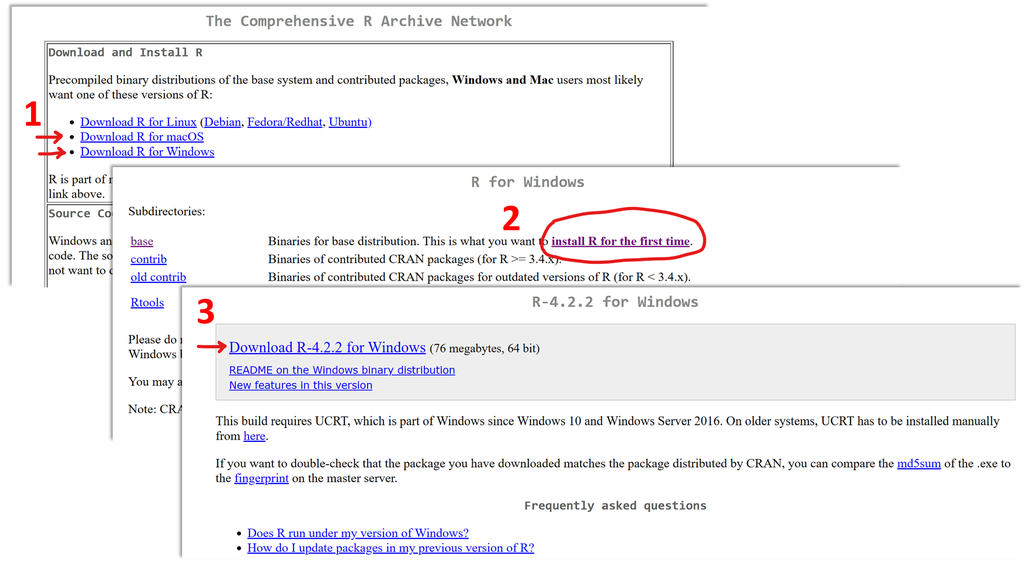

Downloading R for Windows. Mac users: Follow the “Download R for macOS” CRAN link and choose the R version appropriate for your OS and CPU.

2. Install R. Default settings will work for most people. You should not need any shortcuts since RStudio will access R for us.
3. [Download RStudio from Posit.](https://posit.co/download/rstudio-desktop/) (You may need to scroll down the page a bit for downloads for Mac, older versions of Windows, and 32-bit systems).
4. Install RStudio. Default settings should be fine, but now you’ll want to make sure you have an easily accessible shortcut!

# 2 **Navigating RStudio**

### RStudio is divided into 4 movable panes:

1. Console  
This is where we run our R code/commands

2. Source  
This is where we write, run, save, and edit **scripts**, which are text files containing our R code and can consist of many commands built off of each other.

**Note**

You may not see this pane if it’s your first time starting up R Studio because you likely won’t have an open script...more on this soon.

3. Environment, History, Connections, Tutorial  
We use this pane mostly for the Environment, which is where our data, functions, and other objects will be stored and accessed.

4. Files, Plots, Packages, Help, Viewer, Presentation  
I tend to keep this pane minimized until I need it. It can be very handy when you want to access a project file, create a figure, or reference a function’s help section.

**Try it**

You can change pane sizes by clicking and dragging pane edges or by using the buttons in the figure below:

[figure not shown]

Expanding and minimizing panes

### Personalizing Your RStudio

The four panes can be relocated to whichever screen quadrants you’d like:  
`Tools -> Global Options -> Pane Layout`

You can adjust fonts, text sizes, color schemes, etc. under Global Options as well:  
`Tools -> Global Options -> Appearance`

# 3 **Console Calculator**

You can run basic and complex calculations, or even more complicated code, in the Console pane.

**Note**

The colorful lines below are R code! Entering each line of code in the Console yields R output. The `[1]` in the output shows the positional order of the leftmost result your code returned on that line. In this case, it’s a single number on a single line. Many analyses will return multiple results listed one after the other across several lines, so these bracketed numbers can be useful for examining lengthier output. We’ll see this later!

**Try it**

Run some basic calculations by typing or copying them into the Console and hitting the “Enter” or “Return” key.

```r
1 + 1
```

```
[1] 2
```

```r
2 / 4
```

```
[1] 0.5
```

```r
3 * (5 - 3)^2
```

```
[1] 12
```

# 4 **Your First R Script**

The R Console is great for one-off calculations, but what if you want to create, edit, and run code more than once? R scripts can solve this problem!

- Click on the “New File” button (a white square with green plus drop-down under File) and select “R Script
- Now click `File -> Save As...`, give your file a meaningful name like “R_intro_part1”, and save it somewhere you can find it again.

[figure not shown]

Click here to start a new R script!

From here on out, we’ll be entering our code into our new R scripts. All of this could alternatively be run in the Console, but to revisit and edit code entered into the Console, you’d have to double click on past code under the History tab in the Environment panel, cycle through the history using `Ctrl/Cmd + [up arrow]` in the Console, or scroll up and copy/paste code back into the Console.

## Running code in R scripts

There are a few ways to run code contained in a script:

- Run the current line your cursor is on (it doesn’t need to be at the end).
  - Click the `Run` button at the top right corner of your Source pane (above your script)
  - Hit `Ctrl/Cmd + Enter`
- Run the entire script
  - Highlight everything and click `Run`
  - `Ctrl/Cmd + A + Enter`
- Re-run the previous line
  - Click the button immediately to the right of `Run`, which shows a blue arrow turning back and a green arrow pointing forward.
  - `Ctrl/Cmd + Alt/Opt + P`

**Try it**

Run some basic calculations entered into your script.

```r
2 * 3 * 4
```

```
[1] 24
```

```r
1 / 7
```

```
[1] 0.1428571
```

## The Almighty `#`Hashtag

In addition to editing and running our R code, scripts are also great places to organize and **comment** on our code. The R language has reserved the `#` symbol for commenting and organization purposes. Here are some best practices to keep your scripts organized and understandable (always good when returning to your work after time away or sharing with collaborators!).

- Create collapsible sections using `# Section Title ----`
- Annotate your code with comments explaining what the code does and why. Each comment should start at the beginning of a line and should be preceded by a `#` and a single `Space`.
- Mute, or **comment out**, code you *don’t* want to run by putting a `#` in front of it.
  - To comment out multiple lines, highlight them and hit `Ctrl/Cmd + Shft + C`

**Note**

All of these practices are on display below.

# 5 **Creating Objects**

**Objects** in R are containers that store information. Using the `<-` operator (`Alt/Opt + Hyphen [-]`), you can save information as objects in your Environment pane. This is similar to saving a file in a folder on your computer, but you can delete, recreate, rename, and edit that object with the code written in your script.

Assigning data to objects allows you to “call”, or access, the data whenever you want.

## Single-value Numeric Examples

**Try it**

1. Enter the code below in your new script to save some objects, use them in operations, and see the results.  
2. Employ good organizational practices using `#`.

```r
# Creating Objects ----

# Objects can be single values. In the line below, we assign a value to an object with a descriptive name.
ten <- 10

# In this line, we "call" the object, which will produce its value in the Console output when run.
ten

# Objects can also contain the results of calculations or functions.
twenty <- 4 * 5
twenty

# And we can combine objects into more complex calculations.
ten + twenty

# NOTE: object names cannot include spaces. Instead, use underscores to separate words.
ten_twenty <- ten + twenty
ten_twenty + 10

# This code is "commented out" and won't run:
# ten * 2 - twenty
```

Our only output should be the following for our two objects and the two sums we calculated using those objects:

```
## [1] 10
## [1] 20
## [1] 30
## [1] 40
```

## Overwriting Objects

When working in most word processing programs, if you try to save a document with the same name as another file, the program will give you a warning. R does NOT do that, so you need to be organized and intentional with how you name and re-name your objects.

**Try it**

Experiment with reassigning objects.

```r
# Here "math" = 15
math <- 3*5
math
```

```
[1] 15
```

```r
# But as soon as we run this code, every time we call "math" from now on, we'll get 25 instead.
math <- ten + math
math
```

```
[1] 25
```

```r
math - ten_twenty
```

```
[1] -5
```

## Careful!

R is case-sensitive and sensitive to typos, too! In fact, typos are the most common source of errors in R. Any time you’ve got a problem, first **check for typos!**

```r
# Calling this object works as intended.
ten
```

```
[1] 10
```

```r
# This won't work because of incorrect capitalization.
Ten
```

```
Error in eval(expr, envir, enclos): object 'Ten' not found
```

```r
# This typo will yield an error as well.
twetny
```

```
Error in eval(expr, envir, enclos): object 'twetny' not found
```

## Strings/Characters

Data come in many formats, or **classes**. The objects we saved above were all what you might call “integer” or “numeric” classes. Another common data format is the **character** class, or text-based data. In R, **strings** are just character class text data in between quotation marks!

**Try it**

Make and manipulate some string objects.

```r
# Put text in quotations to create a string.
tu <- "Tulane University"
loc <- "New Orleans, LA"

tu
```

```
[1] "Tulane University"
```

```r
loc
```

```
[1] "New Orleans, LA"
```

**Note**

As you might expect, character and numeric classes are incompatible! And strings can’t be used mathematically. What happens if you try to run the code below in your script?

```r
# You can't do math with text
tu + 10

# Nor can you combine string objects in ways you might think, but we'll learn how soon.
tu + loc
tu loc
tu, loc
```

# 6 **Vectors, Functions, Help, Cleaning**

## Vectors

**Vectors** are common objects in R. They’re just lists of variables and can contain numbers, expressions, character strings, and more. You can think of these as analogous to a single column of data in Excel.

To create vectors, we have to use a **function**, which is just a pre-packaged code used to accomplish a specific task. Functions in R are written in the format `function.name(data = ..., arguments = ...)`, where additional `arguments` feed extra instructions to the function on how to manipulate the input `data`.

The function for creating a vector is `c()`. `c` stands for “Combine Values into a Vector or List,” but who wants to write all that out every time?

**Try it**

Create some vectors of your own.

```r
# Vectors ----

# Vectors combine values separated by commas. Here we're telling the c() function to combine three character values. We are not feeding the function any additional arguments.
birds <- c("Kestrel", "Crow", "Robin")
birds
```

```
[1] "Kestrel" "Crow"    "Robin"
```

```r
# This works for numbers as well as characters.
a <- c(1, 2, 3, 4)
a
```

```
[1] 1 2 3 4
```

```r
# But if you combine the two, the numbers will be converted to characters.
# NOTE: We haven't assigned this vector to an object! As a result, it won't appear in your Environment after you run it.
c("a", 1, "b", 2, "c", 3)
```

```
[1] "a" "1" "b" "2" "c" "3"
```

```r
# We can use the colon symbol to create numeric runs from A to B.
a <- c(1:4)
a
```

```
[1] 1 2 3 4
```

```r
# Here's a longer vector.
ten_to_sixty <- c(10:60)

# Notice how we get more [1] in our output now. The numbers will change depending on the width of your Console when you run the code.
# You can experiment with this by dragging your Console edges left or right and rerunning the code.
ten_to_sixty
```

```
 [1] 10 11 12 13 14 15 16 17 18 19 20 21 22 23 24 25 26 27 28 29 30 31 32 33 34
[26] 35 36 37 38 39 40 41 42 43 44 45 46 47 48 49 50 51 52 53 54 55 56 57 58 59
[51] 60
```

## Function examples

R is full of helpful functions, and since it’s entirely open-source, people are always coming up with new ones! This means there’s a pre-packaged function out there for almost all of your needs.

**Try it**

Test out some common functions below. What do they do?

```r
# Function Practice ----

# Here are a few functions that can take additional arguments, but we haven't supplied any. Instead, we're using the default methods and supplying only the input data.
median(a)
sum(a)
mean(ten_to_sixty)

# Here are a couple common functions where we provide input data followed by arguments. What does each argument do?
round(2/3, digits = 2)
round(2/3, digits = 4)

sort(a, decreasing = TRUE)

# Here's a function that takes 2+ sources of input data. In this case, we're inputting a single value (the character string "American") and an object (birds).
# What happens here?
am_birds <- paste("American", birds)
am_birds

# Here we rearrange the order of our input data in paste() and provide an argument where we set `sep` (short for separate) equal to "nothing" as denoted by two quotations with nothing in between them.
# How does this change the results of the paste() function?
paste(birds, "s", sep = "")

# Many functions can take multiple arguments
x <- rep(a, times = 3)
y <- rep(a, each = 3)
z <- rep(a, each = 3, times = 3)

# Compare the output
x
y
z
```

## Help in R

If you’re ever unsure of how a function works, what arguments it takes, or even if you just want examples, R contains the answers! You can search for help in the Help tab of the Files pane. Or…

**Try it**

Query R for help by entering these lines directly into your *console*, not your script, one at a time.

```r
# Entering a ? before a function name will pull up the help page for that function
?c
?paste
?rep
?sort
?round

# If you don't know the name of the function, you may be able to find it by putting two question marks before a keyword.
??student

# Wrap phrases in quotes to search for them.
??"linear regression"
```

**Note**

There are a LOT of great online resources if you want more help in R and RStudio. For starters, you can click the `Help` tab, and then the picture of the Home button. More advanced help can usually be found on [StackOverflow](https://stackoverflow.com/questions/tagged/r) – every R coder’s best friend.

## Avoiding clutter

It’s always a good idea to keep a tidy work space. R has a function called `rm()` (short for “remove”) that you can use to do targeted house cleaning.

- You can always rerun your script to get your objects back after removing them!
- If you want to erase all objects, you can click the broom button in the Environment panel.
  - There are similar “clearing” broom buttons in the Console pane and under the History and Plots tabs.

**Try it**

Let’s get rid of extra objects we don’t need anymore.

```r
rm(a, birds, loc, math, ten, ten_to_sixty, ten_twenty, tu, twenty, x, y, z)
```

# 7 **Data Frames**

If vectors are equivalent to columns in an Excel or .csv file, then **data frames** are equivalent to the file or sheet itself! They’re just one or more rows and one or more columns of data. In R, we commonly create, import, and combine data frames. Let’s combine all three approaches to build a dataframe about those birds from earlier.

## Creating

Like most tabular information, data frames are organized by column. In R, they’re created by column too within `data.frame()`. All we have to do is set a user-defined column name equal to a value, vector, or object.

**Try it**

1. Start a new collapsible section heading.  
2. Next, build your own data frame by defining your columns.  
3. Combine multiple functions to get one end result

```r
# Working with Data Frames ----

# Create data frames using data.frame()
# Here we'll create two columns, one called "species" and one called "family," and we'll fill each column with data.
# NOTE: the indentation here! When code for a single function starts to get too long, it can be hard to visually digest.
# In these instances, hit the "Enter/Return" key after each argument in a function, i.e., after the commas.
# RStudio will automatically indent each new line for us so that they fall below their function's opening parenthesis.
bird_data <- data.frame(species = rep(am_birds, each = 12),
                        family = rep(c("Falconidae", "Corvidae", "Turdidae"),
                                     each = 12))
```

Congratulations! In addition to making your first data frame, you just combined *three* functions for the first time by nesting `c()` inside `rep()` inside `data.frame()`! Take some time to inspect each component of this code to make sure you’re clear on what the three functions did. You may find it helpful to start with the innermost piece (`c()`) and work your way out.

**Note**

When nesting functions, your parentheses really start to pile up. You can put your cursor after a closing parenthesis to highlight its opening parenthesis. One nice perk of RStudio is that it will warn you if you have too many or too few!

## Viewing

Let’s check out our results. There are a few ways to view your them:

1. Type the name of your data frame into the Console and hit Enter.

   ```r
   # NOTE: This gets quite cumbersome for large data sets, especially ones with lots of columns since the Console can't scroll left and right.
   bird_data
   ```

   ```
               species     family
   1  American Kestrel Falconidae
   2  American Kestrel Falconidae
   3  American Kestrel Falconidae
   4  American Kestrel Falconidae
   5  American Kestrel Falconidae
   6  American Kestrel Falconidae
   7  American Kestrel Falconidae
   8  American Kestrel Falconidae
   9  American Kestrel Falconidae
   10 American Kestrel Falconidae
   11 American Kestrel Falconidae
   12 American Kestrel Falconidae
   13    American Crow   Corvidae
   14    American Crow   Corvidae
   ```

   [output cut: 22 more lines]

2. Use the `View()` function. *WARNING*: this function *must* be capitalized! BUT, it’s a lot more manageable than trying to inspect big data directly in the Console. Usually you don’t want to put `View()` in your script, however, so type or copy it into your Console instead. You should have the same results open up in a new tab beside your script in the Source panel.

   ```r
   View(bird_data)
   ```

[figure not shown]

   Viewing your data frame should open a new tab in your Source panel that looks like this.

3. Lastly, you can click on the name of your data frame in the Environment tab for the same effect. Note also that the Environment tab will show you how many rows (obs.) your data frame contains and how many columns (variables). We can also see that the `am_birds` object is a character class (chr) containing three values.

[figure not shown]

   You can click here instead of using View().

## Importing

If you’re working through this tutorial, you probably have data of your own that you hope to analyze in R! Let’s learn how to import data from other sources.

**Note**

It’s good practice to use .csv files for data import and export. They’re less bulky (which makes R run much faster and leaves more memory for analyses and object storage), there are fewer odd formatting issues, you don’t have to deal with sheets, and they’re more easily shared across platforms.

**Try it**

1. Import some bird measurement data to accompany this tutorial directly from the web.  
2. Download the file, copy the complete file path (location on your computer) including the file name and the .csv extension to your clipboard.  
3. **Read in** the data to R using `read.csv()` with the appropriate set up for your machine.  
4. Examine your new data using one of the methods above.

```r
# Data can be imported into R from various sources. Here you'll learn how to do it directly from the web and from your own machine.

# In both cases, we'll use read.csv() because that's the filetype of the data we're importing.

# When files are hosted directly on a website, you can import it by quoting the file's url inside the read.csv function.
bird_csv <- read.csv("https://libguides.tulane.edu/ld.php?content_id=70580527")

# You can use this same function to import local data from your machine by feeding the file path into the function. You can try this out by downloading the data file from the link above or from the "Data_In" folder in this project's GitHub repository (https://github.com/mellisbirds/Intro_to_R.git).

# Here's how it works:

# Windows users must replace the \ in their pathways with / or \\ in order for R to recognize it.
bird_csv <- read.csv("C:/Users/Jane Doe/Desktop/intro1_bird_data.csv")

# For Mac Users:
bird_csv <- read.csv("/Users/Jane Doe/Desktop/intro1_bird_data.csv")

# Now that you've read in the new data, look it over using what you learned earlier.
```

**Notes**

In *Intro to R Part II*, we’ll learn about project management, which makes importing and exporting data much more efficient!

The data I’ve provided for importing practice are fictional data I created, but they’re based on actual average values from Tobias et al. (2022).  
Tobias, Joseph A., et al. “AVONET: morphological, ecological and geographical data for all birds.” *Ecology Letters* 25.3 (2022): 581-597.

## Combining

There are several different ways to combine data frames in r, but the most straightforward “bind” data frames together by column or row. Unsurprisingly, column binding adds the columns of one data frame *beside* those of another; row binding adds the rows of one column *underneath* the rows of another. The functions for these two methods are `cbind()` and `rbind()`, respectively.

**Note**

If your rows or columns don’t match up before binding, they won’t match up after binding either using this approach!

**Try it**

Combine the data you created with bird names and families with the measurement data you imported.

```r
# cbind() takes multiple data or object inputs, but they must have the same number of rows.

# Do our data have the same number of rows? What about columns?

# Objects within the function's parentheses will be bound together in the order you enter them.
bird_data <- cbind(bird_data, bird_csv)

# NOTE: You just overwrote the bird_data object! If you accidentally run the code above again, you will bind bird_csv to the new object, which will result in duplicate columns! If necessary, go back a few steps to recreate the original bird_data object.
```

# 8 **Examine Data**

It’s always a good idea to inspect your data. Here are some common ways of doing so:

**Try it**

Give data frame inspection a whirl. Pay special attention to the last bit of output from `str()`

```r
# Data Inspection ----

# In addition to View(), you can also use functions to examine pieces of your data and its structure.

colnames(bird_data)
nrow(bird_data)
head(bird_data, n = 5)
tail(bird_data, n = 3)

# This one also shows object and data classes!
str(bird_data) # str = structure
```

Does anything unusual from the `str()` output catch your eye?

```
'data.frame':   36 obs. of  5 variables:
 $ species       : chr  "American Kestrel" "American Kestrel" "American Kestrel" "American Kestrel" ...
 $ family        : chr  "Falconidae" "Falconidae" "Falconidae" "Falconidae" ...
 $ id            : chr  "kestrel1" "kestrel2" "kestrel3" "kestrel4" ...
 $ wing_length_mm: num  175 179 201 183 NA ...
 $ mass_g        : num  109 NA 130 113 112 ...
```

# 9 **Common Data Manipulators**

## `$`

When examining the `str()` output, you probably noticed dollar signs (`$`) in front of our data frame’s column names and **`NAs`** in some of the numeric columns. Those `NAs` stand for “Not Available”, and it’s equivalent to a blank cell in Excel; it’s an empty space in our data frame with missing data.

But let’s look at `$` before we get any further with `NAs`. In R, we can use **`$`** to reference columns within our dataframe. The `str()` output above uses them to tell us, hey, these are your columns!

**Try it**

1. Use the `$` operator to access and edit individual variables in an object, in this case, columns in a data frame.  
2. Use `$` to create and remove columns.

```r
# $ Operator ----

# You may have also noticed some differences in significant figures in our numeric variables while inspecting the data above.
head(bird_data$wing_length_mm, 5)
## [1] 175.3 179.2 200.7 182.8    NA

head(bird_data$mass_g, 5)
## [1] 108.732      NA 129.515 112.586 112.163
```

```r
# We can overwrite columns with edited versions of themselves using $ and <- . Let's fix the sig figs on mass_g by setting the mass_g column equal to a rounded version of itself.
bird_data$mass_g <- round(bird_data$mass_g, digits = 1)

# Check to make sure mass_g is now rounded to 1 decimal place.
head(bird_data$mass_g)
```

```
[1] 108.7    NA 129.5 112.6 112.2 131.6
```

```r
# You can also use $ to make new columns altogether or eliminate existing ones. Let's try both.

# First, we can determine the relationship between mass and wing length by dividing the former by the latter.
bird_data$mass_to_wing <- round(bird_data$mass_g / bird_data$wing_length_mm, 2)

# Perhaps we don't need that ID column. We can assign it `NULL` to remove it.
bird_data$id <- NULL

# Remember to check your work! $id should have disappeared.
head(bird_data, 4)
```

```
           species     family wing_length_mm mass_g mass_to_wing
1 American Kestrel Falconidae          175.3  108.7         0.62
2 American Kestrel Falconidae          179.2     NA           NA
3 American Kestrel Falconidae          200.7  129.5         0.65
4 American Kestrel Falconidae          182.8  112.6         0.62
```